# Data_Results_Ideas

10/18/2017

## Data and Results Presentation Ideas:

#### Goal: Present in a meaningful and concise way the index hopping landscape of our data…

The outcome of the experiment indicated that a vast majority of our reads were *not* affected by index hopping, especially those of high quality (sic). To prove this, we could sort the reads that had index swapping from our reads that did not (basically doing what Pete ultimately wanted us to do in the original index hopping assignment) by modifying the python code of the last summer assignment a little. See below (and in the github repo):

```python
#Quality and Index swapping: Our goal is to look through the lane of sequencing generated from your library preps and
#determine the level of index swapping and undetermined index-pairs, before and after quality filtering of index reads

#The program will take in the four fastq files, a qscore limit, and a text file containing all adapter indexes as inputs and filter each read
#based on the qscore limit. Because in our quality cutoff discernment step we determined a cutoff based on average quality per read, we will only throw out
#reads that have indexes with an *average* quality score below the cutoff (rather than throwing out a read if ANY of the nucleotides fall below threshold).
#Reads that pass filter are sorted by index pairs; reads that have indexes that are not among the possible index pairs
#(a la mutation or index hopping) are sorted into an 'Unknown Index' dictionary item, and the rest are sorted into their respective index pair dictionary item.


## Argparse arguments - 4 fastq files (read1, read2, index1, index2), quality threshold, and index.tsv file
import argparse as ap

def get_arguments():
    parser = ap.ArgumentParser(description="Quality and Index Hopping filter")
    parser.add_argument("-q_cut", help="Quality score cut-off threshold for filtering reads", required=True, type=int)
    parser.add_argument("-r1", help="Filename for read1 fastq", required=True, type=str)
    parser.add_argument("-r2", help="Filename for read2 fastq", required=True, type=str)
    parser.add_argument("-i1", help="Filename for index1 fastq", required=True, type=str)
    parser.add_argument("-i2", help="Filename for index2 fastq", required=True, type=str)
    parser.add_argument("-indf", help="Text file containing all possible indexes", required=True)
    return parser.parse_args()

args = get_arguments()

# from the passed in arguments:
qcutoff = args.q_cut
indexes = args.indf

#First, we create a dictionary, and store all possible index pairs (order matters) as keys.
#The value for each key will be the number of counts that the index pair has been seen across all reads
ind_pairs = dict()

import itertools as it
with open(indexes,'r') as indx:
    sequences = []
    for line in indx:
        ind = line.split('\t')[1].strip('\n')

        sequences.append(ind)   #Grab all our indexes and put them in a list

    perms = it.product(sequences, repeat=2) #Create a product of all possible index pairs (including the index with itself)
    for p in perms:
        ind_pairs[p] = 0  # Initialize each pair as a key in the dict and the value to 0

# Additionally, let's add a dictionary key for our reads that do not have a possible index pair (for the reads with 'N' or that have had
# a point mutation in the index that may push it out of the possible pairs).
ind_pairs['Unknown'] = 0

#Next, we both quality filter and sort our sequencing reads/indexes into files baised on the index pairing of each read.
#We start by defining a function that will read in lines from our files in set of 4, such that we capture only one fastq entry at a time:
def four_line_grouper(file, n):
    read = it.islice(file, n)
    return read

r1 = open(args.r1,'r')
r2 = open(args.r2,'r')
i1 = open(args.i1,'r')
i2 = open(args.i2,'r')

for i in range(0,363246734):
    read1 = [x for x in four_line_grouper(r1,4)]
    read2 = [x for x in four_line_grouper(r2,4)]
    index1 = [x for x in four_line_grouper(i1,4)]
    index2 = [x for x in four_line_grouper(i2,4)]

    complement = {'A': 'T', 'C': 'G', 'G': 'C', 'T': 'A'} #Complement dict for transforming index 2 to reverse complement
    keep1 = True  #Flags for keeping the read, one for each index
    keep2 = True

    ind1_qual_ave = 0 # Set a value to store the quality score average for each index
    ind2_qual_ave = 0

    for char in index1[3].strip('\n'):  #Loop through every value in the quality string for index1
        qual = (ord(char)-33)
        ind1_qual_ave += qual

    for char in index2[3].strip('\n'):  #Loop through every value in the quality string for index2
        qual = (ord(char)-33)
        ind2_qual_ave += qual

    ind1_qual_ave = ind1_qual_ave/8  # Divide by the number of nucleotides in the index
    ind2_qual_ave = ind2_qual_ave/8

    if ind1_qual_ave < qcutoff:
            keep1 = False    #If the index ave qual falls below the quality cutoff, flip the quality flag
            #print(ind1_qual_ave)

    if ind2_qual_ave < qcutoff:
            keep2 = False    #If the index ave qual  falls below the quality cutoff, flip the quality flag

    if keep1 == True and keep2 == True:               #Check to see both indexes passed quality check
        ind1 = index1[1].strip('\n')
        ind2 = index2[1].strip('\n')

        if 'N' not in ind2:                     # Check to see if the index has N; if it does, we don't need to take reverse compliment because we already know it won't match known index pair.
            ind2 = ind2[::-1]                        #Need to make the reverse complement of the second index
            ind2 = list(ind2)
            for i in range(0,len(ind2)):
                ind2[i] = complement[ind2[i]]

            ind2 = ''.join(ind2)

        index_pair = (ind1,ind2)
        #print(index_pair)


        if index_pair in ind_pairs:   #If the read has passed quality, and is in the possible list of index pairs:

            read1[0] = read1[0].split(' ')[0]+'_'+ind1+'_'+ind2+'\n'
            read2[0] = read2[0].split(' ')[0]+'_'+ind1+'_'+ind2+'\n'
            index1[0] = index1[0].split(' ')[0]+'_'+ind1+'_'+ind2+'\n'
            index2[0] = index2[0].split(' ')[0]+'_'+ind1+'_'+ind2+'\n'

            ind_pairs[index_pair] += 1 #if the index pair of this is in the dictionary of index pairs, increment the count for that pairing
            #Then, append the reads to the "Known Index pair" files:

            with open('Known_index_pair_R1.fastq', 'a') as r1w:
                r1w.write(''.join(read1))

            with open('Known_index_pair_R2.fastq', 'a') as i1w:
                i1w.write(''.join(index1))

            with open('Known_index_pair_R3.fastq', 'a') as i2w:
                i2w.write(''.join(index2))

            with open('Known_index_pair_R4.fastq', 'a') as r2w:
                r2w.write(''.join(read2))

        elif index_pair not in ind_pairs:   #If the read has passed quality but does not contain a possible index pair:

            ind_pairs['Unknown'] += 1  #Increment the count of the 'Unknown' item, for reads with indexes outside the possible set

            read1[0] = read1[0].split(' ')[0]+'_'+ind1+'_'+ind2+'\n'
            read2[0] = read2[0].split(' ')[0]+'_'+ind1+'_'+ind2+'\n'
            index1[0] = index1[0].split(' ')[0]+'_'+ind1+'_'+ind2+'\n'
            index2[0] = index2[0].split(' ')[0]+'_'+ind1+'_'+ind2+'\n'

            #Write the read to the "Unknown Index pair" files:

            with open('Unknown_index_pair_R1.fastq','a') as r1w:
                r1w.write(''.join(read1))

            with open('Unknown_index_pair_R2.fastq','a') as i1w:
                i1w.write(''.join(index1))

            with open('Unknown_index_pair_R3.fastq','a') as i2w:
                i2w.write(''.join(index2))

            with open('Unknown_index_pair_R4.fastq','a') as r2w:
                r2w.write(''.join(read1))

r1.close()
r2.close()
i1.close()
i2.close()

print("Total number of records that passed quality filtering:",sum(ind_pairs.values()))
out = open(('Index_Pair_Counts_'+str(qcutoff)+'.txt'),'w')
for item in ind_pairs.items():
    out.write(str(item[0])+'\t'+str(item[1])+'\n')

out.close()
```

The output files here could be run through FastQC to get quality profiles on basically two groups: Reads with Index Hopping and Reads without. These graphs could be included in the paper/presentation:

```bash
ml fastqc/0.11.5
>$ fastqc --noextract -o Known_QC_analysis /{path}/{to}/{files}/Known_index_pair_R1.fastq /{path}/{to}/{files}/Known_index_pair_R4.fastq
>$fastqc --noextract -o Known_QC_analysis /{path}/{to}/{files}/Unknown_index_pair_R1.fastq /{path}/{to}/{files}/Unknown_index_pair_R4.fastq
```

Additionally, we could look at what index-hopping pairs most often occured; here is a dot-plot representation of that using the counts per index pair file produced out of the Index Hopping python script:

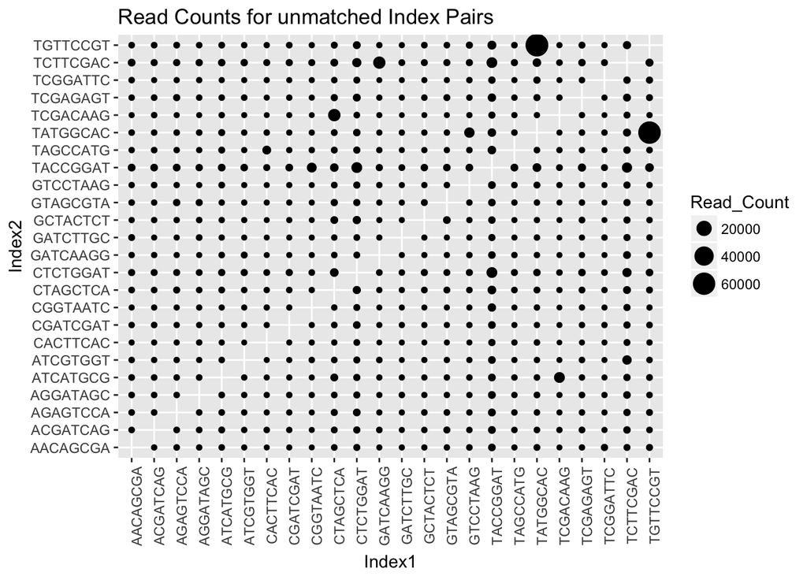

```
##           V1       V2    V3
## 25  TATGGCAC TGTTCCGT 63153
## 26  TGTTCCGT TATGGCAC 61181
## 27  CTAGCTCA TCGACAAG  9926
## 28  GATCAAGG TCTTCGAC  9552
## 29  TCGACAAG ATCATGCG  5896
## 30  CTCTGGAT TACCGGAT  5821
## 31  TACCGGAT CTCTGGAT  5796
## 32  TACCGGAT TCTTCGAC  5626
## 33  GTCCTAAG TATGGCAC  4869
## 34  TCTTCGAC TACCGGAT  4550
## 35  CGGTAATC TACCGGAT  3861
## 36  TCTTCGAC ATCGTGGT  3083
## 37  CTCTGGAT TCTTCGAC  2776
## 38  TCTTCGAC CTCTGGAT  2747
```

[output cut: 538 more lines]

As the conclusions/interpretation group can point out, the most represented indexes come from the libraries with the the largest read counts from among the pooled set.